# Multi-Step Processes and Workflow Systems

## Index

- 1. What Are Multi-Step Processes?
- 2. Core Problem
- 3. Single Server Orchestration
- 4. Single Server Orchestration With State
- 5. Event Sourcing
- 6. Event Sourcing vs Event-Driven Architecture
- 7. Workflow Systems
- 8. Durable Execution Engines
- 9. Temporal Core Concepts
- 10. How Temporal Works Internally
- 11. Signals and External Events
- 12. Managed Workflow Systems
- 13. Temporal vs Step Functions vs Airflow
- 14. When to Use Workflow Systems
- 15. When NOT to Use Workflow Systems
- 16. Sagas and Compensation
- 17. Common Interview Examples
- 18. Common Deep Dives - Overview
- 19. Deep Dive 1 - Workflow Versioning
- 20. Deep Dive 2 - Workflow Migration
- 21. Deep Dive 3 - Workflow State Size
- 22. Deep Dive 4 - External Events
- 23. Deep Dive 5 - Exactly Once Execution
- 24. Deep Dive 6 - Idempotency
- 25. Deep Dive 7 - Retry and Timeout Strategy
- 26. Deep Dive 8 - Compensation Failure
- 27. Deep Dive 9 - Worker Crash Recovery
- 28. Deep Dive 10 - Observability and Debugging
- 29. Interview Decision Tree
- 30. Golden Interview Answer

## 1. What Are Multi-Step Processes?

Multi-step processes are business workflows that involve many steps, services, retries, failures, waiting periods, and compensation logic.

Examples:

- E-commerce order fulfillment
- Payment processing
- Uber ride matching
- Loan approval
- Insurance claims
- Travel booking

Simple example:

```
Place Order
    ↓
Charge Payment
    ↓
Reserve Inventory
    ↓
Create Shipping Label
    ↓
Wait for Human Pickup
    ↓
Send Confirmation Email
```

The main challenge is that each step can fail, timeout, retry, or take a long time.

⬆ Back to Index

## 2. Core Problem

Real production systems are not just one database write or one API call.

They usually involve:

- Multiple services
- External systems
- Human approvals
- Payment gateways
- Shipping providers
- Notifications
- Long-running tasks

Example failure:

```
Payment succeeds
Inventory reservation fails
```

Now the system must refund the payment.

Without a proper design, this creates:

- Lost state
- Duplicate actions
- Partial completion
- Hard-to-debug failures
- Manual recovery
- Complex retry logic

⬆ Back to Index

## 3. Single Server Orchestration

This is the simplest approach.

The API server calls each service one by one.

```
API Server
    ↓
Payment Service
    ↓
Inventory Service
    ↓
Shipping Service
    ↓
Email Service
```

Good for:

- Simple flows
- Short request/response operations
- Low failure complexity

Problems:

- Server crash loses workflow state
- Hard to resume from the failed step
- Difficult compensation logic
- Poor scalability
- Callbacks/webhooks are hard to route
- Error handling becomes scattered

Example issue:

```
Server charges payment
Server crashes before reserving inventory
```

When the server restarts, it may not know what already happened.

⬆ Back to Index

## 4. Single Server Orchestration With State

To improve single-server orchestration, we can persist state after each step.

```
API Server
    ↓
Database State Checkpoint
    ↓
Next Step
    ↓
Database State Checkpoint
```

This helps because servers can restart and read workflow state from the database.

But it creates new problems:

- You manually build a state machine
- Multiple API servers may pick the same work
- Compensation logic is still manual
- Retry logic becomes complex
- State transitions become hard to maintain

This approach often becomes an operational burden in production.

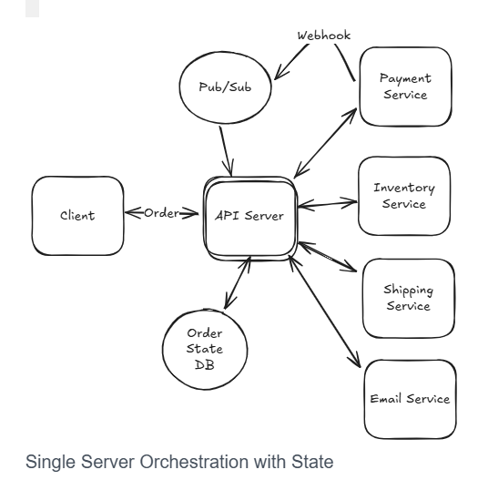

⬆ Back to Index

## 5. Event Sourcing

Event sourcing stores the history of what happened instead of only storing the latest state.

Example events:

```
OrderPlaced
PaymentCharged
InventoryReserved
OrderShipped
EmailSent
```

Typical storage:

- Kafka
- Redis Streams
- Durable log
- Event store

Flow:

```
API Service
    ↓
OrderPlaced Event
    ↓
Payment Worker
    ↓
PaymentCharged Event
    ↓
Inventory Worker
    ↓
InventoryReserved Event
```

Benefits:

- Fault tolerance
- Scalability
- Complete audit trail
- Easier replay
- Workers can recover after crashes
- New workers can be added for scale

Drawbacks:

- More infrastructure
- Harder debugging
- Event lineage can be difficult
- Monitoring needs to be strong
- Workflow logic is spread across workers

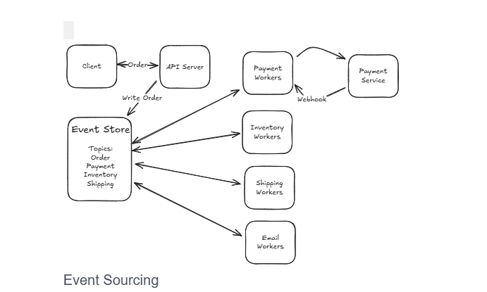

  ⬆ Back to Index

## 6. Event Sourcing vs Event-Driven Architecture

Event-driven architecture focuses on services publishing and consuming events to decouple systems.

Event sourcing focuses on storing the full event history so state can be reconstructed.

Simple difference:

| Concept | Main Goal |
| --- | --- |
| Event-Driven Architecture | Decouple services using events |
| Event Sourcing | Persist every state-changing event |
| Workflow System | Orchestrate long-running business process |

Event sourcing can be used to build workflows, but you usually need extra infrastructure for retries, compensation, visibility, and orchestration.

⬆ Back to Index

## 7. Workflow Systems

Workflow systems are purpose-built systems for reliable multi-step processes.

They handle:

- State persistence
- Retries
- Recovery
- Compensation
- Long waits
- Timeouts
- External signals
- Audit trail
- Worker failure recovery

Main idea:

```
Business Workflow Code
        ↓
Workflow Engine
        ↓
Activities / Services
```

If a worker crashes:

```
Crash
  ↓
Workflow engine reads history
  ↓
Another worker resumes from last successful step
```

This avoids manually building state machines and retry logic.

⬆ Back to Index

## 8. Durable Execution Engines

Durable execution lets workflow code survive crashes, deployments, and machine failures.

The workflow can pause, resume, retry, and continue from the last completed step.

Popular tools:

| Tool | Notes |
| --- | --- |
| Temporal | Most powerful open-source durable execution engine |
| Cadence | Earlier Uber workflow engine |
| Azure Durable Functions | Azure-native durable workflows |

Temporal is commonly used in system design interviews because it clearly supports long-running, reliable workflows.

⬆ Back to Index

## 9. Temporal Core Concepts

Temporal has two main concepts:

## Workflow

The high-level business process.

Example:

```
Order Fulfillment Workflow
```

## Activity

An individual step in the process.

Examples:

```
Process Payment
Reserve Inventory
Ship Order
Send Email
Refund Payment
```

Workflow example:

```
Process Payment
    ↓
Reserve Inventory
    ↓
Ship Order
    ↓
Send Email
```

If inventory reservation fails:

```
Refund Payment
```

⬆ Back to Index

## 10. How Temporal Works Internally

Temporal records workflow progress in a history database.

It stores:

- Workflow decisions
- Activity results
- Timers
- Signals
- Retries
- State transitions

If a workflow worker crashes:

```
New Worker
    ↓
Replay Workflow History
    ↓
Reuse previous activity results
    ↓
Continue from unfinished step
```

Important rules:

## Workflows must be deterministic

Same input and same history should produce the same decisions.

Avoid non-deterministic logic directly inside workflow code, such as:

- Random values
- Current timestamp
- External API calls

## Activities must be idempotent

Activities may be retried, so repeating them with the same input should be safe.

⬆ Back to Index

## 11. Signals and External Events

Signals allow a workflow to wait for an external event.

Use cases:

- Customer signs a document
- Driver accepts a ride
- Human approves a loan
- Payment gateway sends webhook
- Warehouse confirms pickup

Example:

```
Workflow sends document
    ↓
Workflow waits
    ↓
Customer signs after 5 days
    ↓
Signal received
    ↓
Workflow resumes
```

Benefits:

- No polling
- No thread blocked
- Efficient waiting
- Good for human-in-the-loop systems

[figure not shown]

  ⬆ Back to Index

## 12. Managed Workflow Systems

Managed workflow systems define workflows declaratively, usually as DAGs or state machines.

Examples:

| Tool | Best For |
| --- | --- |
| AWS Step Functions | AWS-native service orchestration |
| Google Cloud Workflows | GCP-native workflows |
| Apache Airflow | Scheduled ETL/data pipelines |

AWS Step Functions example style:

```
{
  "StartAt": "ProcessPayment",
  "States": {
    "ProcessPayment": {
      "Type": "Task",
      "Next": "ReserveInventory"
    }
  }
}
```

Pros:

- Serverless
- Easy visualization
- Managed infrastructure
- Good cloud integrations

Cons:

- Verbose
- Less expressive than code
- State size and duration limits may apply

⬆ Back to Index

## 13. Temporal vs Step Functions vs Airflow

| Feature | Temporal | AWS Step Functions | Airflow |
| --- | --- | --- | --- |
| Style | Code-based workflow | JSON/YAML state machine | DAG |
| Best For | Complex business workflows | AWS service orchestration | ETL/data pipelines |
| Long-running workflows | Excellent | Good | Limited |
| Event-driven workflows | Excellent | Good | Weak |
| Human waiting | Excellent | Good | Weak |
| Operational overhead | Higher | Lower | Medium |
| Expressiveness | High | Medium | Medium |
| Interview default | Strong default | Mention for AWS-heavy systems | Use for data pipelines |

Interview tip:

Default to Temporal for complex business workflows unless the system is simple and AWS-heavy.

⬆ Back to Index

## 14. When to Use Workflow Systems

Use workflow systems when you see:

- Multiple dependent steps
- Long-running process
- Human approval
- External callbacks
- Need for retries
- Need for compensation
- Complex state machine
- Strong audit requirement
- Process can run for minutes, hours, days, or weeks

Recognition phrases in interviews:

```
If step X fails, undo step Y
```

```
Wait for user approval
```

```
Resume after server crash
```

```
Track every state transition
```

```
Make sure the process eventually completes
```

⬆ Back to Index

## 15. When NOT to Use Workflow Systems

Do not use workflow systems for everything.

Avoid workflows for:

- Simple CRUD APIs
- Single-step async jobs
- Simple email sending
- Image resizing
- Low-value high-volume small tasks
- Latency-sensitive synchronous APIs

Better alternatives:

| Scenario | Better Solution |
| --- | --- |
| Send one email | Message queue |
| Resize image | Worker queue |
| CRUD operation | Normal service/database |
| Simple async task | Queue + worker |
| Scheduled ETL | Airflow |

Interview maturity means starting simple and adding workflows only when needed.

⬆ Back to Index

## 16. Sagas and Compensation

A saga is a multi-step transaction where each step commits independently.

If a later step fails, earlier steps are undone using compensating actions.

Example:

```
Step 1: Charge Payment
Step 2: Reserve Inventory
Step 3: Ship Order
```

If inventory fails:

```
Compensation: Refund Payment
```

Saga characteristics:

- No long-running distributed transaction
- Each step commits separately
- Temporary inconsistency is allowed
- Compensation handles failures
- Often implemented using workflow engines

Workflow engines are a good way to implement sagas reliably.

⬆ Back to Index

## 17. Common Interview Examples

| System | Workflow Reason |
| --- | --- |
| E-commerce order | Payment → Inventory → Shipping → Email |
| Payment system | Retries, refunds, external gateways |
| Uber ride flow | Request → Driver accept → Trip start → Payment |
| Loan approval | Human approval, documents, compliance checks |
| Insurance claim | Long-running review and approval |
| Travel booking | Flight + hotel + car booking with compensation |
| Food delivery | Restaurant accept → Driver assign → Delivery |
| Document signing | Wait for external user action |

Good interview phrase:

```
Since this is a long-running multi-step process with failures and compensation, I would use a workflow engine like Temporal.
```

⬆ Back to Index

## 18. Common Deep Dives - Overview

Interviewers often go deeper into workflow edge cases.

Main deep dives:

1. Workflow versioning
2. Workflow migration
3. Workflow state size
4. External events and signals
5. Exactly-once execution
6. Idempotency
7. Retry and timeout strategy
8. Compensation failure
9. Worker crash recovery
10. Observability and debugging

These are important because workflow systems solve reliability problems, but they introduce their own design tradeoffs.

⬆ Back to Index

## 19. Deep Dive 1 - Workflow Versioning

Problem:

```
10,000 workflows are already running
You deploy a new workflow with an extra step
```

Question:

What happens to workflows that started with the old definition?

Solution:

Use workflow versioning.

```
Old workflows → Continue with V1
New workflows → Start with V2
```

Pros:

- Simple
- Safe
- Easy to reason about

Cons:

- Old workflows may take days or weeks to finish
- New behavior is not applied immediately to old executions

Use when:

- Existing workflows can complete using old logic
- Immediate migration is not required

⬆ Back to Index

## 20. Deep Dive 2 - Workflow Migration

Workflow migration updates running workflows safely.

Useful when:

- You must apply new behavior to active workflows
- Old workflow path is no longer acceptable
- Compliance/business logic changed

In durable execution systems, use deterministic patching.

Example:

```
if workflow.patched("new-compliance-check"):
    run_new_compliance_check()
else:
    run_old_logic()
```

Why this matters:

Workflow replay must remain deterministic.

If you simply change old code, replay can break because the workflow history does not match the new code path.

⬆ Back to Index

## 21. Deep Dive 3 - Workflow State Size

Problem:

Workflow history keeps growing.

This can happen when:

- Workflow runs for months
- Many activities execute
- Large payloads are stored
- Many signals are received

Issues:

- Slower replay
- More storage
- Higher memory usage
- Harder debugging

Solutions:

## Pass IDs, not big payloads

Instead of storing:

```
Large customer document
```

Store:

```
document_id
```

and fetch the document from object storage or database when needed.

## Continue-As-New

Restart the workflow with a compact state.

```
Old workflow history
    ↓
Continue-As-New
    ↓
New workflow with small input
```

⬆ Back to Index

## 22. Deep Dive 4 - External Events

Problem:

Workflow must wait for something outside the system.

Examples:

- Customer signs a document
- Driver accepts a ride
- Payment provider sends webhook
- Human approves request

Bad approach:

```
Poll every few seconds
```

Better approach:

Use signals.

```
External Event
    ↓
Signal Workflow
    ↓
Workflow Resumes
```

Benefits:

- Efficient
- No polling
- Good for long waits
- Works for human-in-the-loop processes

Also add timeout handling:

```
Wait 30 days
If no signal → Send reminder
Wait 7 more days
If no signal → Cancel workflow
```

⬆ Back to Index

## 23. Deep Dive 5 - Exactly Once Execution

Question:

How do we ensure a step runs exactly once?

Important answer:

True exactly-once execution is very hard in distributed systems.

Workflow engines can guarantee that a completed activity result is recorded, but if the activity succeeds and the acknowledgement is lost, the engine may retry.

Example:

```
Payment charged
ACK lost
Workflow retries payment
```

This can cause duplicate charges unless handled properly.

Solution:

Use idempotency keys.

```
payment_id = order_id + payment_attempt
```

Before charging:

```
Check if payment_id already processed
If yes, return previous result
If no, process payment
```

⬆ Back to Index

## 24. Deep Dive 6 - Idempotency

Idempotency means running the same operation multiple times has the same effect as running it once.

Examples:

Safe:

```
Create payment with idempotency key ORDER123
```

Unsafe:

```
Charge card blindly every retry
```

Common idempotency strategy:

1. Generate unique idempotency key
2. Store it in database
3. Before action, check if key exists
4. If exists, return saved result
5. If not, execute action and store result

Use idempotency for:

- Payments
- Refunds
- Emails
- Order creation
- Inventory reservation
- Webhook processing

⬆ Back to Index

## 25. Deep Dive 7 - Retry and Timeout Strategy

Workflows need controlled retries.

Common retry settings:

- Max attempts
- Exponential backoff
- Timeout per activity
- Overall workflow timeout
- Non-retryable errors

Example:

```
Retry payment gateway timeout 3 times
Do not retry invalid card error
```

Good strategy:

| Error Type | Action |
| --- | --- |
| Network timeout | Retry |
| 500 error | Retry with backoff |
| Invalid input | Do not retry |
| Payment declined | Do not retry |
| Rate limit | Retry after delay |

Retries must be paired with idempotency.

⬆ Back to Index

## 26. Deep Dive 8 - Compensation Failure

Question:

What if the compensation also fails?

Example:

```
Inventory failed
Refund payment also fails
```

Solution options:

- Retry compensation
- Put compensation into dead-letter queue
- Alert operations team
- Mark workflow as failed-needs-manual-review
- Use reconciliation jobs
- Store failure state durably

Important interview point:

Compensation is not always perfect.

Some actions cannot be fully undone.

Example:

- Email already sent
- External shipment already created
- User already saw confirmation

So design intermediate states like:

```
PENDING
CONFIRMED
FAILED
MANUAL_REVIEW
```

⬆ Back to Index

## 27. Deep Dive 9 - Worker Crash Recovery

Question:

What happens if a worker crashes in the middle of a workflow?

Workflow engine handles recovery.

```
Worker crashes
    ↓
Workflow engine detects incomplete task
    ↓
Another worker picks it up
    ↓
Workflow history is replayed
    ↓
Execution continues
```

Previously completed activities are not re-executed if their results were recorded in history.

If an activity was running but not recorded as completed, it may be retried.

Therefore activities must be idempotent.

⬆ Back to Index

## 28. Deep Dive 10 - Observability and Debugging

Workflow systems need strong observability.

Track:

- Workflow ID
- Current state
- Activity attempts
- Retry count
- Failure reason
- Timeout reason
- Compensation status
- External signal history
- Start and end time

Useful tools:

- Workflow UI
- Logs
- Metrics
- Tracing
- Alerts
- Dead-letter queues
- Audit history

Important interview phrase:

```
I would expose workflow status and history so support teams can debug stuck or failed workflows.
```

⬆ Back to Index

## 29. Interview Decision Tree

Use this decision tree:

```
Is it one step?
    ↓
Use queue or normal service

Is it multi-step?
    ↓
Maybe workflow

Can steps fail independently?
    ↓
Workflow

Need compensation?
    ↓
Workflow / Saga

Need to wait minutes, hours, or days?
    ↓
Workflow

Need human approval or webhook callback?
    ↓
Workflow

Need audit trail and recovery?
    ↓
Workflow
```

⬆ Back to Index

## 30. Golden Interview Answer

A strong interview answer:

```
For a long-running multi-step process, I would use a workflow engine like Temporal.
The workflow defines the business process, and activities perform individual external actions like payment, inventory, shipping, and notification.
Temporal persists workflow history, retries failed activities, resumes after crashes, and supports signals for external events.
For failures, I would use compensating activities like refunds or inventory release.
All activities that interact with external systems must be idempotent using idempotency keys.
```

This answer shows:

- Reliability thinking
- Failure handling
- Compensation awareness
- Distributed systems maturity
- Practical tool knowledge

⬆ Back to Index

Kafka keeps messages based on retention:

retention.ms = 7 days retention.bytes = 100 GB On Disk

For a normal e-commerce system, I would choose event-driven architecture using Kafka because services like order, payment, inventory, shipping, and notification need asynchronous communication. I would use event sourcing only for specific parts like payment ledger or audit-heavy order history where events must be the source of truth.